# I. Gradient Descent

### Definition

- Graident Descent is an optimization algorithm.
- Its goal is **to minimize the error function**
  - We can think of it as walking down from a mountain trying to reach the ground in the shortest possible way (find the the lowest error value).

### How does it work?

We start by defining random initial parameters and from there the Gradient Descent iteratively adjusts them (using calculus) so that they minimize the given loss function.

### Why do we need Gradient Descent?

By minimizing the loss with respect to the network parameters, we can find configurations where the loss is at a minimum and **the network is able to predict the correct labels with high accuracy.**

# II. Steps of Gradient Descent

## STEP 1 - Start with some random weights

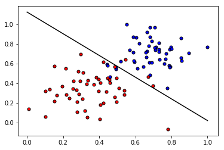

```python
## import the packages
import matplotlib.pyplot as plt
import numpy as np
import pandas as pd
from sklearn import svm


# Some helper functions for plotting and drawing lines
def plot_points(X, y):
    admitted = X[np.argwhere(y==1)]
    rejected = X[np.argwhere(y==0)]
    plt.scatter([s[0][0] for s in rejected], [s[0][1] for s in rejected], s = 25, color = 'blue', edgecolor = 'k')
    plt.scatter([s[0][0] for s in admitted], [s[0][1] for s in admitted], s = 25, color = 'red', edgecolor = 'k')

def display(m, b, color='g--'):
    plt.xlim(-0.05,1.05)
    plt.ylim(-0.05,1.05)
    x = np.arange(-10, 10, 0.1)
    plt.plot(x, m*x+b, color)

# reading in and plotting the data
data = pd.read_csv('data.csv', header=None)
# features + labels
X = np.array(data[[0,1]])
y = np.array(data[2])
plot_points(X,y)
#plt.show()

# using svm to plot linear boundary
C = 1.0  # SVM regularization parameter
clf = svm.SVC(kernel = 'linear',  gamma=0.7, C=C )
clf.fit(X,y)
w = clf.coef_[0]
a = -w[0] / w[1]
xx = np.linspace(0, 1)
yy = a * xx - (clf.intercept_[0]) / w[1]

plt.plot(xx, yy, 'k-')
```

```python
# features + targets --> given in the data.csv
features = X
targets = y
```

### 1.1 Define the activation function

#### Sigmoid activation function

$$\sigma(x) = \frac{1}{1+e^{-x}}$$

**sigmoid function:**

squeezes the input values between 0 and 1

really useful for providing a probability

if you want your NN to output a probability, then sigmoid is what you want to use

### PYTHON HELP

> `np.exp(x)`: calculate the exponential of all elements in the input array

> `array.shape`: see the shape of the array

> `np.random.normal(scale=1.0, size=None)`
> - Draw random samples from a normal (Gaussian) distribution.
> - input values:
>   - scale: standard deviation (spread or “width”) of the distribution
>   - size: output shape

> [Numpy Arrays](http://cs231n.github.io/python-numpy-tutorial/#numpy-arrays)  
> [np.exp (Documentation)](https://docs.scipy.org/doc/numpy/reference/generated/numpy.exp.html) [ndarray.shape (Documentation)](https://docs.scipy.org/doc/numpy/reference/generated/numpy.ndarray.shape.html)  
> [np.random.normal (Documentation)](https://docs.scipy.org/doc/numpy/reference/generated/numpy.random.normal.html)

```python
# Activation (sigmoid) function
def sigmoid(x):
    return 1/(1+np.exp(-x))
```

### 1.2 - Define the output (prediction) formula

We start with some random weights: $ w_1,...,w_n, b $

which will give us a probability function (a line that separates the points):

$$\hat{y} = \sigma(w_1 x_1 + w_2 x_2 + b)$$

```python
# Output (prediction) formula
def output_formula(features, weights, bias):
    return sigmoid(np.dot(features, weights) + bias)
```

#### Testing out our functions

```python
print('Shape of features: ', features.shape)
print('Features - example: ', features[0:3])

# number of features
n_features = features.shape[1]
```

```
Shape of features:  (100, 2)
Features - example:  [[ 0.78051  -0.063669]
 [ 0.28774   0.29139 ]
 [ 0.40714   0.17878 ]]
```

```python
# weights --> random generate a sample for weights
weights = np.random.normal(scale=1 / n_features**.5, size=n_features)
print('Shape of weights: ', weights.shape)
print('Weights: ', weights)
```

```
Shape of weights:  (2,)
Weights:  [-0.26679569 -0.46058922]
```

```python
# set the bias to 0
bias = 0

# testing the output_formula
output_formula(features, weights, bias)
```

```
array([0.45539107, 0.44745006, 0.45240273, 0.43236343, 0.42598704,
       0.46906904, 0.44362513, 0.43504453, 0.42861399, 0.45570615,
       0.48371539, 0.45317058, 0.43419921, 0.42343607, 0.4190551 ,
       0.44885522, 0.44250413, 0.45158914, 0.42296507, 0.43326921,
       0.42698236, 0.42155464, 0.41545345, 0.45648363, 0.41136125,
       0.40126231, 0.42448468, 0.45718474, 0.47140374, 0.43161191,
       0.44475303, 0.46912714, 0.42289037, 0.40329636, 0.44341487,
       0.45267177, 0.40292069, 0.42197601, 0.42688029, 0.43795901,
       0.43101334, 0.39177841, 0.4647896 , 0.4021157 , 0.48624836,
       0.46491954, 0.41991019, 0.4216106 , 0.45718924, 0.43708939,
       0.35246825, 0.40352161, 0.37010008, 0.36351647, 0.40022239,
       0.34964562, 0.36166816, 0.36844272, 0.38270373, 0.36730777,
       0.40576513, 0.36525945, 0.38656763, 0.37490748, 0.3838144 ,
       0.36843689, 0.39092175, 0.40355778, 0.40886961, 0.36189407,
       0.34642778, 0.38582495, 0.3540552 , 0.38152756, 0.3931471 ,
       0.36228034, 0.37308921, 0.36909985, 0.38477056, 0.38061587,
       0.37924005, 0.37627419, 0.37045056, 0.38991838, 0.41677434,
       0.36398124, 0.39774237, 0.35837975, 0.3768868 , 0.36198171,
       0.34832637, 0.3795927 , 0.3822189 , 0.36403933, 0.36856908,
       0.3708511 , 0.37149765, 0.40468691, 0.34897293, 0.39514934])
```

## STEP 2 - Define the error (loss) function

For every point, we calculate the error.

The error is

- high for the misclassified points and
- small fo correctly classified points

#### Log-loss error function

$$Error(y, \hat{y}) = - y \log(\hat{y}) - (1-y) \log(1-\hat{y})$$

**Log-loss error function:**

classification loss function

measures the performance of a classification model where the prediction input is a probability value between 0 and 1

quantifies the accuracy of a classifier by penalising false classifications

minimising the log-loss is basically equivalent to maximising the accuracy of the classifier

- We will use Gradient Descent to minimize this error function.
- We are going to try to jiggle the line around to see how we can decrease the error function.
  - This will give rise to new weights W' and b' which will give us better predictions: $$\sigma(W'x + b') $$

### PYTHON HELP

> `np.log(x)`: Natural logarithm, element-wise.

> [np.log (Documentation)](https://docs.scipy.org/doc/numpy/reference/generated/numpy.log.html)

```python
# Error (log-loss) formula
def error_formula(y, output):
    return  -y*np.log(output) - (1 - y) * np.log(1-output)
```

#### Testing out our function

```python
output = output_formula(features, weights, bias)
error_formula(y, output)
```

```
array([0.78659874, 0.80419035, 0.7931825 , 0.83848877, 0.85334635,
       0.75700531, 0.81277538, 0.83230689, 0.84719857, 0.78590709,
       0.72625858, 0.79148667, 0.83425185, 0.85935274, 0.86975287,
       0.80105489, 0.81530549, 0.79498249, 0.86046568, 0.83639601,
       0.85101257, 0.86380588, 0.87838471, 0.78420244, 0.88828349,
       0.91313994, 0.85687937, 0.78266773, 0.75204035, 0.84022845,
       0.81023614, 0.75688147, 0.86064231, 0.90808361, 0.81324946,
       0.79258799, 0.90901554, 0.86280681, 0.85125165, 0.82562995,
       0.84161623, 0.93705887, 0.76617044, 0.91101543, 0.72103575,
       0.76589091, 0.86771442, 0.86367313, 0.78265788, 0.82761756,
       0.43458745, 0.51671227, 0.46219433, 0.45179674, 0.51119634,
       0.43023786, 0.448897  , 0.45956664, 0.48240619, 0.45777118,
       0.52048063, 0.45453894, 0.48868526, 0.46985561, 0.48420706,
       0.45955741, 0.49580853, 0.5167729 , 0.52571867, 0.44925097,
       0.42530224, 0.48747529, 0.43704123, 0.48050265, 0.49946885,
       0.4498565 , 0.46695103, 0.46060768, 0.48576001, 0.47902963,
       0.47681083, 0.47204442, 0.46275089, 0.49416253, 0.5391811 ,
       0.45252722, 0.50706996, 0.44375866, 0.47302708, 0.44938832,
       0.4282114 , 0.47737908, 0.48162109, 0.45261856, 0.45976674,
       0.46338732, 0.46441552, 0.5186678 , 0.42920405, 0.5027737 ])
```

## STEP 3 - The Gradient Descent Step

#### Learning rate:

**Learning rate:**

it determines how big steps the Gardient Descent takes into the direction of the local minimum (i.e. how fast or slow we will move towards the optimal weights)

we have to set the it to an appropriate value, which is neither too low nor too high

### 3.1. Update weights

For every point (coordinates) $x_1,...,x_n$ we update $ w_i $ by adding the learning rate $\alpha$ times the partial derivative of the error function respect to $ w_i $:

$$ w_i \longrightarrow w_i + \alpha (y - \hat{y}) x_i$$

$$ b \longrightarrow b + \alpha (y - \hat{y})$$

```python
# Gradient descent step
def update_weights(x, y, weights, bias, learnrate):
    output = output_formula(x,weights,bias)
    wi = weights + ((learnrate*(y - output))*x)
    b = bias + (learnrate*(y-output))
    return wi, b
```

```python
np.zeros(weights.shape)
```

```
array([0., 0.])
```

### 3.2. Repeat

We have 2 options - repeat:

- until the error is small OR
- a fixed number of times (epochs)

This case we will go with the second one.

### PYTHON HELP

> `zip(*iterators)`: Make an iterator that aggregates elements from each of the iterables.

> [zip (Documentation)](https://docs.python.org/3.3/library/functions.html#zip)

#### Testing out our function

```python
# we set learning rate and epoch
learnrate = 0.01
epochs = 10
```

```python
# calculating the gradient descent
for e in range(epochs):
    del_w = np.zeros(weights.shape)
    for x, y in zip(features, targets):
        output = output_formula(x, weights, bias)
        error = error_formula(y, output)
        weights, bias = update_weights(x, y, weights, bias, learnrate)
print('FINAL VALUES: weight = ',  weights, 'bias = ', bias)
```

```
FINAL VALUES: weight =  [-0.72345177 -0.96905335] bias =  0.5165207878138504
```

**Rule of Gradient Descent:**

- closer the label to the prediction, smaller the gradient
- farther the label from the prediction, larger the gradient

## Putting it all together: Training function

- This function will help us iterate the gradient descent algorithm through all the data, for a number of epochs.
- It will also plot the data, and some of the boundary lines obtained as we run the algorithm.

```python
np.random.seed(44)

epochs = 100
learnrate = 0.01

def train(features, targets, epochs, learnrate, graph_lines=False):

    # 1. CALCULATING THE GRADIENT DESCENT

    errors = []
    n_records, n_features = features.shape
    last_loss = None
    weights = np.random.normal(scale=1 / n_features**.5, size=n_features)
    bias = 0
    for e in range(epochs):
        del_w = np.zeros(weights.shape)
        for x, y in zip(features, targets):
            output = output_formula(x, weights, bias)
            error = error_formula(y, output)
            weights, bias = update_weights(x, y, weights, bias, learnrate)

    # 2. CALCULATING LOG-LOSS

        # Printing out the log-loss error on the training set
        out = output_formula(features, weights, bias)
        loss = np.mean(error_formula(targets, out))
        errors.append(loss)
        if e % (epochs / 10) == 0:  # 10 updates with the current training loss and accuracy
            print("\n========== Epoch", e,"==========")
            if last_loss and last_loss < loss:
                print("Train loss: ", loss, "  WARNING - Loss Increasing")
            else:
                print("Train loss: ", loss)
            last_loss = loss
            predictions = out > 0.5
            accuracy = np.mean(predictions == targets)
            print("Accuracy: ", accuracy)
        if graph_lines and e % (epochs / 100) == 0:
            display(-weights[0]/weights[1], -bias/weights[1])

    # 3. PLOTTING THE RESULTS

    # Plotting the solution boundary
    plt.title("Solution boundary")
    display(-weights[0]/weights[1], -bias/weights[1], 'black')

    # Plotting the data
    plot_points(features, targets)
    plt.show()

    # Plotting the error
    plt.title("Error Plot")
    plt.xlabel('Number of epochs')
    plt.ylabel('Error')
    plt.plot(errors)
    plt.show()
```

## Time to train the algorithm!

When we run the function, we'll obtain the following:

- 10 updates with the current training loss and accuracy
- A plot of the data and some of the boundary lines obtained. The final one is in black. Notice how the lines get closer and closer to the best fit, as we go through more epochs.
- A plot of the error function. Notice how it decreases as we go through more epochs.

```
========== Epoch 0 ==========
Train loss:  0.7135845195381634
Accuracy:  0.4

========== Epoch 10 ==========
Train loss:  0.6225835210454962
Accuracy:  0.59

========== Epoch 20 ==========
Train loss:  0.5548744083669508
Accuracy:  0.74

========== Epoch 30 ==========
Train loss:  0.501606141872473
Accuracy:  0.84

========== Epoch 40 ==========
Train loss:  0.4593334641861401
Accuracy:  0.86

========== Epoch 50 ==========
Train loss:  0.42525543433469976
Accuracy:  0.93

========== Epoch 60 ==========
Train loss:  0.3973461571671399
Accuracy:  0.93

========== Epoch 70 ==========
Train loss:  0.3741469765239074
Accuracy:  0.93

========== Epoch 80 ==========
Train loss:  0.35459973368161973
Accuracy:  0.94

========== Epoch 90 ==========
Train loss:  0.3379273658879921
Accuracy:  0.94
```

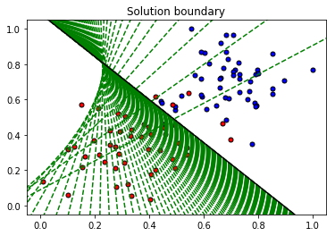

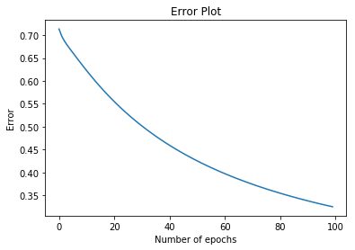

```python
#equivalent to: train(features = X, targets = y, epochs = epochs, learnrate = learnrate, graph_lines = True)
train(features, targets, epochs, learnrate, True)
```

## Resources

### Udacity Resources

[Original Notebook](https://github.com/udacity/deep-learning-v2-pytorch/blob/master/intro-neural-networks/gradient-descent/GradientDescent.ipynb)  
[Minimizing the error function](https://youtu.be/KayqiYijlzc)  
[Gradient Descent](https://youtu.be/rhVIF-nigrY)  
[Logistic Regression Algortihm](https://youtu.be/snxmBgi_GeU)

### Other Resources

[Define decision doundary with SVM](https://stackoverflow.com/questions/22294241/plotting-a-decision-boundary-separating-2-classes-using-matplotlibs-pyplot)

[Introduction to Gradient Descent Algorithm (along with variants) in Machine Learning](https://www.analyticsvidhya.com/blog/2017/03/introduction-to-gradient-descent-algorithm-along-its-variants/)  
[Gradient Descent in a Nutshell](https://towardsdatascience.com/gradient-descent-in-a-nutshell-eaf8c18212f0)